# BT_GROUP5

HoThanhThuy

2022-03-31

### Bài 1: Sử dụng phương pháp Stepwise với tiêu chí AIC để xác định mô hình

*Link data: https://www.kaggle.com/code/renaudgendron/multiple-linear-regression-price/data*

## 1.1)Giải thích ý nghĩa của các biến trong mô hình:

Bộ dữ liệu **“Real estate.csv”** được thu thập để giải thích giá nhà theo thời gian tại một khu vực. Dữ liệu gồm các biển sau:

**X1** transaction date: Thời gian xảy ra giao dịch mua bán nhà (specific time zone)

**X2** house age: Tuổi của ngôi nhà (năm)

**X3** distance to the nearest MRT station: Khoảng cách gần nhất từ ngôi nhà đi đến sân ga(mét)

**X4** number of convenience stores: Số cửa hàng tiện lợi gần ngôi nhà

**X5** latitude: Vĩ độ

**Y** house price of unit area: Giá bán ngôi nhà (currency/m^2) (Currency được hiểu là đơn vị tiền tệ do vùng quy định)

Ở đây ta cần chọn mô hình phù hợp để giải thích cho sự biến động của giá nhà theo thời gian

## 1.2) Chọn mô hình:

**1.2.1) Thống kê mô tả:**

```r
#Read data from file
setwd("C:/Users/phuon/Downloads/RStudio/R/win-library/4.1")
data_1<-read.csv("Real estate.csv",TRUE,",")
head(data_1)
```

```
##   No X1.transaction.date X2.house.age X3.distance.to.the.nearest.MRT.station
## 1  1            2012.917         32.0                               84.87882
## 2  2            2012.917         19.5                              306.59470
## 3  3            2013.583         13.3                              561.98450
## 4  4            2013.500         13.3                              561.98450
## 5  5            2012.833          5.0                              390.56840
## 6  6            2012.667          7.1                             2175.03000
##   X4.number.of.convenience.stores X5.latitude X6.longitude
## 1                              10    24.98298     121.5402
## 2                               9    24.98034     121.5395
## 3                               5    24.98746     121.5439
## 4                               5    24.98746     121.5439
## 5                               5    24.97937     121.5425
## 6                               3    24.96305     121.5125
##   Y.house.price.of.unit.area
## 1                       37.9
## 2                       42.2
## 3                       47.3
## 4                       54.8
## 5                       43.1
## 6                       32.1
```

```r
#Change name cols and remove "No" col
data_1<-data_1[,2:8]#remove col "no" in data
names(data_1)=c('X1','X2','X3','X4','X5','X6','Y')#change cols name
head(data_1)
```

```
##         X1   X2         X3 X4       X5       X6    Y
## 1 2012.917 32.0   84.87882 10 24.98298 121.5402 37.9
## 2 2012.917 19.5  306.59470  9 24.98034 121.5395 42.2
## 3 2013.583 13.3  561.98450  5 24.98746 121.5439 47.3
## 4 2013.500 13.3  561.98450  5 24.98746 121.5439 54.8
## 5 2012.833  5.0  390.56840  5 24.97937 121.5425 43.1
## 6 2012.667  7.1 2175.03000  3 24.96305 121.5125 32.1
```

```r
#Descriptive Statistics
#install.packages("pastecs")
library('pastecs')
stat.desc(data_1,desc = F)
```

```
##                  X1     X2           X3   X4          X5          X6       Y
## nbr.val     414.000  414.0    414.00000  414   414.00000   414.00000   414.0
## nbr.null      0.000   17.0      0.00000   67     0.00000     0.00000     0.0
## nbr.na        0.000    0.0      0.00000    0     0.00000     0.00000     0.0
## min        2012.667    0.0     23.38284    0    24.93207   121.47353     7.6
## max        2013.583   43.8   6488.02100   10    25.01459   121.56627   117.5
## range         0.916   43.8   6464.63816   10     0.08252     0.09274   109.9
## sum      833443.674 7333.0 448728.67521 1695 10337.17845 50314.81149 15723.8
```

Ta thấy data gồm có 414 dòng và 7 cột (trong đó gồm 6 biến giải thích X1-X6 và một biến phụ thuộc y, không tồn tại giá trị missing value. Range của biến X3 khá lớn nên có thể nhận định biến X3 sẽ có nhiều giá trị outlier, cần đặc biệt quan tâm khi loại outlier của biến này.

**1.2.2)Xử lý các giá trị để đảm bảo chất lượng dữ liệu trước khi hồi quy:**

*a)Xét hiện tượng đa cộng tuyến:*

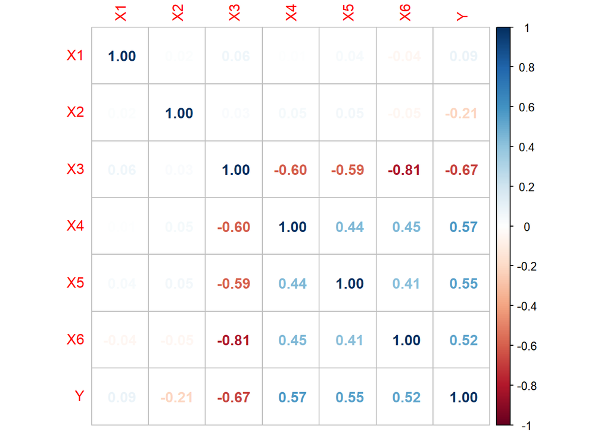

Dựa vào corplot ta có nhận xét cần quan tâm đến sự tương quan giữa biến (X3 ,X6 với hệ số tương quan là 0.81). Tuy nhiên, để chắc chắn hơn ta xét hệ số tương quan VIF

```r
#install.package("car")
library('car')
model_all<-lm(Y~.,data = data_1)
vif(model_all)
```

```
##       X1       X2       X3       X4       X5       X6
## 1.014674 1.014287 4.323019 1.617038 1.610234 2.926302
```

Vì VIF của cả 6 biến giải thích đều nhỏ hơn 5 nên ta có thể nhận xét là không tồn tại hiện tượng đa cộng tuyến giữa các biến giải thích.

*b)Loại bỏ các giá trị ngoại lai trong tập:*

```r
dim(data_1)
```

```
## [1] 414   7
```

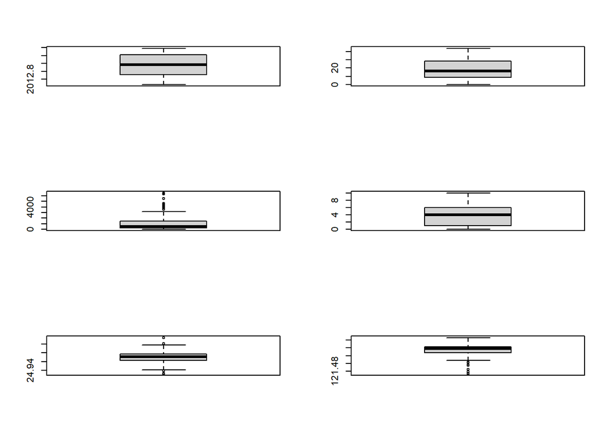

```r
op <- par(mfrow=c(3,2))
boxplot(data_1$X1)
boxplot(data_1$X2)
boxplot(data_1$X3)
boxplot(data_1$X4)
boxplot(data_1$X5)
boxplot(data_1$X6)
```

Với boxplot ta thấy biến X3, X5, X6 có tồn tại giá trị ngoại lai. Ta xét chi tiết từng biến để quyết định rõ xem loại các quan trắc nào.

**• Với biến X3:**

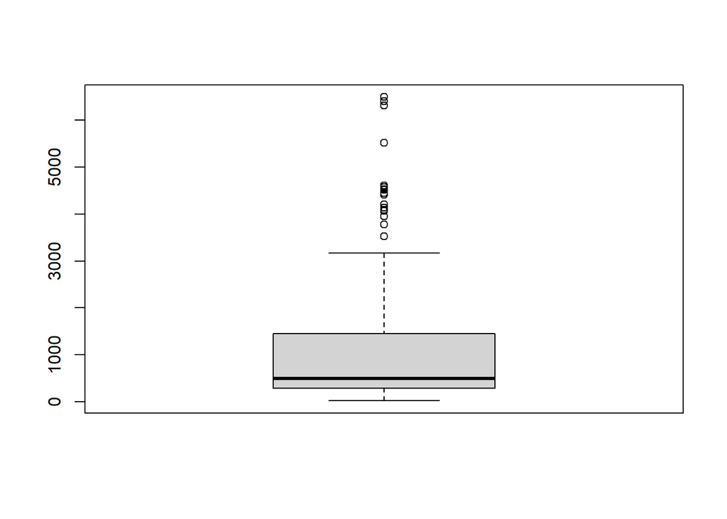

```r
boxplot(data_1$X3)
```

```r
out <- boxplot.stats(data_1$X3)$out
out_ind_3 <- which(data_1$X3 %in% c(out))
out_ind_3
```

```
##  [1]   9  31  36  41  42  49  50  59  74  88  90 117 118 149 155 156 163 171 177
## [20] 181 184 190 195 227 232 233 250 256 299 321 330 332 348 383 385 395 410
```

Với biến X3 ta nhận thấy có đến 37 giá trị outlier. Loại 37 quan trắc này đồng nghĩa vói việc loại gần 10% dữ liệu. Do đó, ta chỉ nên loại các giá trị cực ngoại lai. Ở đây dựa vào boxplot ta chỉ remove các giá trị X3 lớn hơn 5000.

```r
out_ind_3<- which(data_1$X3>=5000)
out_ind_3
```

```
## [1]   9 117 250 256 348
```

```r
data_1<-data_1[-c(9,117,250,256,348),]
dim(data_1)
```

```
## [1] 409   7
```

Lúc này, số quan trắc còn lại là 409.

**• Với biến X5:**

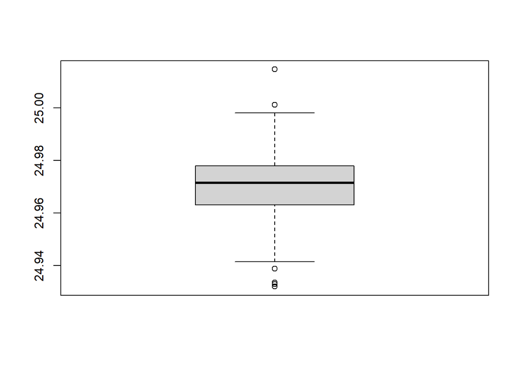

```r
boxplot(data_1$X5)
```

```r
#view index data outlier
out <- boxplot.stats(data_1$X5)$out
out_ind_5 <- which(data_1$X5 %in% c(out))
out_ind_5
```

```
## [1]  35 116 147 193 227 317 326 378
```

```r
data_1<-data_1[-c(35,116,147,193,227,317,326,378),]
dim(data_1)
```

```
## [1] 401   7
```

**• Với biến X6:**

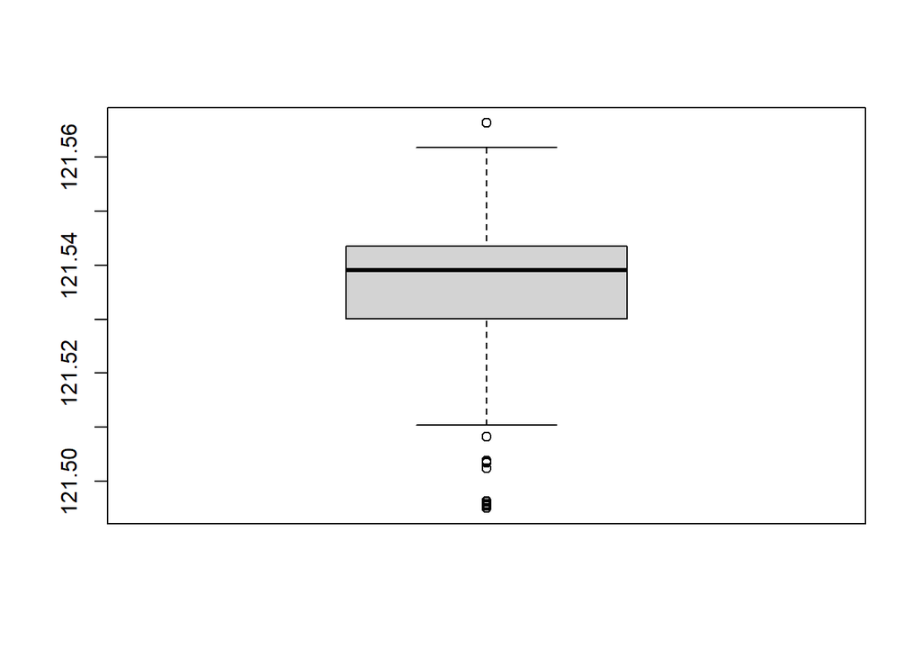

```r
boxplot(data_1$X6)
```

```r
#view index outlier
out <- boxplot.stats(data_1$X6)$out
out_ind_6 <- which(data_1$X6 %in% c(out))
out_ind_6
```

```
##  [1]  30  39  40  47  48  57  72  82  86  88 150 151 158 166 172 176 179 183 185
## [20] 221 225 226 290 299 321 341 372 382 397
```

Vì số lượng outlier của biến X6 khá lớn nên dựa vào boxplot ta sẽ loại bỏ các giá trị ngoại lai nhỏ hơn 121.50 ra khỏi data.

```r
out_ind_6<- which(data_1$X6<=121.50)
out_ind_6
```

```
##  [1]  30  47  48  57 166 172 176 226 321 382
```

```r
#remove outlier X6
data_1<-data_1[-c(30,47,48,57,166,176,226,321,382),]
dim(data_1)
```

```
## [1] 392   7
```

*Số quan trắc còn lại là 392/414. Ta thấy số lượng loại các quan trắc có giá trị outlier khá nhỏ so với số lượng quan trắc của tập dữ liệu nên sẽ không ảnh hưởng hoặc ảnh hưởng rất nhỏ đến kết quả hồi quy mô hình.*

**1.2.3) Lựa chọn mô hình:**

*Sử dụng phương pháp Stepwise với tiêu chí AIC để chọn mô hình.*

```r
model_price<-lm(Y~.,data = data_1)
d1=step(model_price,direction = c("backward"))
```

```
## Start:  AIC=1695.7
## Y ~ X1 + X2 + X3 + X4 + X5 + X6
##
##        Df Sum of Sq   RSS    AIC
## - X6    1       0.0 28604 1693.7
## <none>              28604 1695.7
## - X1    1     703.2 29308 1703.2
## - X5    1    1850.9 30455 1718.3
## - X4    1    1902.4 30507 1718.9
## - X3    1    4307.5 32912 1748.7
## - X2    1    4371.8 32976 1749.5
##
## Step:  AIC=1693.7
## Y ~ X1 + X2 + X3 + X4 + X5
##
##        Df Sum of Sq   RSS    AIC
## <none>              28604 1693.7
## - X1    1     703.4 29308 1701.2
## - X5    1    1897.9 30502 1716.9
## - X4    1    1905.8 30510 1717.0
## - X2    1    4372.2 32976 1747.5
## - X3    1    7054.2 35659 1778.1
```

Kết quả cho ra mô hình với AIC=1693.7 với các biến X1-X5 là tốt nhất. Tiếp theo ta đi kiểm định lại ý nghĩa của các biến trong mô hình.

```r
summary(d1)
```

```
##
## Call:
## lm(formula = Y ~ X1 + X2 + X3 + X4 + X5, data = data_1)
##
## Residuals:
##     Min      1Q  Median      3Q     Max
## -35.660  -4.997  -0.967   4.134  73.813
##
## Coefficients:
##               Estimate Std. Error t value Pr(>|t|)
## (Intercept) -1.575e+04  3.300e+03  -4.773 2.57e-06 ***
## X1           4.812e+00  1.562e+00   3.081  0.00221 **
## X2          -2.920e-01  3.801e-02  -7.681 1.31e-13 ***
## X3          -6.198e-03  6.353e-04  -9.757  < 2e-16 ***
## X4           9.531e-01  1.879e-01   5.071 6.15e-07 ***
## X5           2.447e+02  4.836e+01   5.061 6.48e-07 ***
## ---
## Signif. codes:  0 '***' 0.001 '**' 0.01 '*' 0.05 '.' 0.1 ' ' 1
##
## Residual standard error: 8.608 on 386 degrees of freedom
## Multiple R-squared:  0.5781, Adjusted R-squared:  0.5726
## F-statistic: 105.8 on 5 and 386 DF,  p-value: < 2.2e-16
```

**1.2.4) Một số kiểm định**

*a) Kiểm định sai số có phân phối chuẩn N(0,σ)*

```r
#shapiro test
r=lm(formula = Y ~ X1 + X2 + X3 + X4 + X5, data = data_1)
shapiro.test(r$residuals)
```

```
##
##  Shapiro-Wilk normality test
##
## data:  r$residuals
## W = 0.86239, p-value < 2.2e-16
```

Với giả thuyết H(0) là sai số tuân theo phân phối chuẩn. Giá trị P-value ở trên nhỏ hơn mức ý nghĩa 0.001 nên ta bác bỏ H(0). Tức sai số không tuân theo phân phối chuẩn.

*b) Kiểm định tính ổn định của phương sai:*

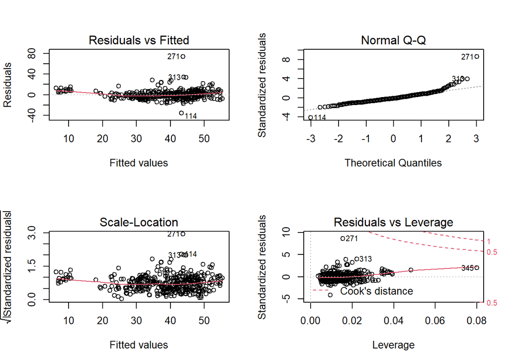

```r
#plot
op <- par(mfrow=c(2,2))
plot(r)
```

```r
#bptest
#install.packages("lmtest")
library('lmtest')
bptest(r)
```

```
##
##  studentized Breusch-Pagan test
##
## data:  r
## BP = 5.1961, df = 5, p-value = 0.3924
```

Với giả thuyết H(0) là phương sai không đổi, Giá trị p-value =0.39, vậy ta không đủ cơ sở để bác bỏ H(0) tức phương sai không có sự thay đổi.

## 1.3)Chuẩn hóa dữ liệu để kết quả có thể thu được tốt hơn hay không

Với y=log(y).

```r
data_1$Y<-log(data_1$Y)
head(data_1)
```

```
##         X1   X2         X3 X4       X5       X6        Y
## 1 2012.917 32.0   84.87882 10 24.98298 121.5402 3.634951
## 2 2012.917 19.5  306.59470  9 24.98034 121.5395 3.742420
## 3 2013.583 13.3  561.98450  5 24.98746 121.5439 3.856510
## 4 2013.500 13.3  561.98450  5 24.98746 121.5439 4.003690
## 5 2012.833  5.0  390.56840  5 24.97937 121.5425 3.763523
## 6 2012.667  7.1 2175.03000  3 24.96305 121.5125 3.468856
```

Tiếp tục sử dụng Stepwise để lựa chọn mô hình.

```r
model_p<-lm(Y~.,data = data_1)
d2=step(model_p,direction = c("backward"))
```

```
## Start:  AIC=-1218.89
## Y ~ X1 + X2 + X3 + X4 + X5 + X6
##
##        Df Sum of Sq    RSS     AIC
## - X6    1    0.0093 16.889 -1220.7
## <none>              16.880 -1218.9
## - X1    1    0.4068 17.287 -1211.6
## - X4    1    1.2431 18.123 -1193.0
## - X5    1    2.4159 19.296 -1168.5
## - X2    1    2.8800 19.760 -1159.1
## - X3    1    3.6510 20.531 -1144.1
##
## Step:  AIC=-1220.68
## Y ~ X1 + X2 + X3 + X4 + X5
##
##        Df Sum of Sq    RSS     AIC
## <none>              16.889 -1220.7
## - X1    1    0.4099 17.299 -1213.3
## - X4    1    1.2368 18.126 -1195.0
## - X5    1    2.4270 19.316 -1170.0
## - X2    1    2.8847 19.774 -1160.9
## - X3    1    6.3875 23.277 -1096.9
```

Với AIC=-1220.68 ta thu được mô hình tốt nhất gồm các biến giải thích X1-X5. Ta tiến hành kiểm định lại ý nghĩa của các biến trong mô hình.

```r
summary(d2)
```

```
##
## Call:
## lm(formula = Y ~ X1 + X2 + X3 + X4 + X5, data = data_1)
##
## Residuals:
##      Min       1Q   Median       3Q      Max
## -1.67487 -0.09573  0.01366  0.10166  1.01586
##
## Coefficients:
##               Estimate Std. Error t value Pr(>|t|)
## (Intercept) -4.486e+02  8.019e+01  -5.594 4.20e-08 ***
## X1           1.162e-01  3.796e-02   3.061  0.00236 **
## X2          -7.500e-03  9.237e-04  -8.120 6.35e-15 ***
## X3          -1.865e-04  1.544e-05 -12.082  < 2e-16 ***
## X4           2.428e-02  4.567e-03   5.317 1.79e-07 ***
## X5           8.751e+00  1.175e+00   7.448 6.27e-13 ***
## ---
## Signif. codes:  0 '***' 0.001 '**' 0.01 '*' 0.05 '.' 0.1 ' ' 1
##
## Residual standard error: 0.2092 on 386 degrees of freedom
## Multiple R-squared:  0.6743, Adjusted R-squared:  0.6701
## F-statistic: 159.9 on 5 and 386 DF,  p-value: < 2.2e-16
```

Sau khi lấy log(Y) ta thấy mô hình có ý nghĩa với 67.43% dữ liêu của biến X giải thích cho Y (giá bán). Giá bán nhà Y sẽ có mối quan hệ tuyến tính thuận với biến X1, X4, X5 và mối quan hệ tuyến tính nghịch với X2, X3.

*Kiểm định sai số có phân phối chuẩn N(0,σ)*

```r
rs=lm(formula = Y ~ X1 + X2 + X3 + X4 + X5, data = data_1)
shapiro.test(rs$residuals)
```

```
##
##  Shapiro-Wilk normality test
##
## data:  rs$residuals
## W = 0.90083, p-value = 2.676e-15
```

Sau khi lấy log(Y) ta thấy mô hình thu được với các biến X1 (transaction date), X2(house age) ,X3(distance to the nearest MRT station) ,X4(number of convenience stores), X5(latitude) đều có ý nghĩa trong mô hình giải thchs cho biến Y (giá nhà). Với 67.43% dữ liêu của biến X giải thích cho Y (giá bán). Giá bán nhà Y sẽ có mối quan hệ tuyến tính thuận với biến X1, X4, X5 và mối quan hệ tuyến tính nghịch với X2, X3.

*Kiểm định lại tính chuẩn của sai số:*

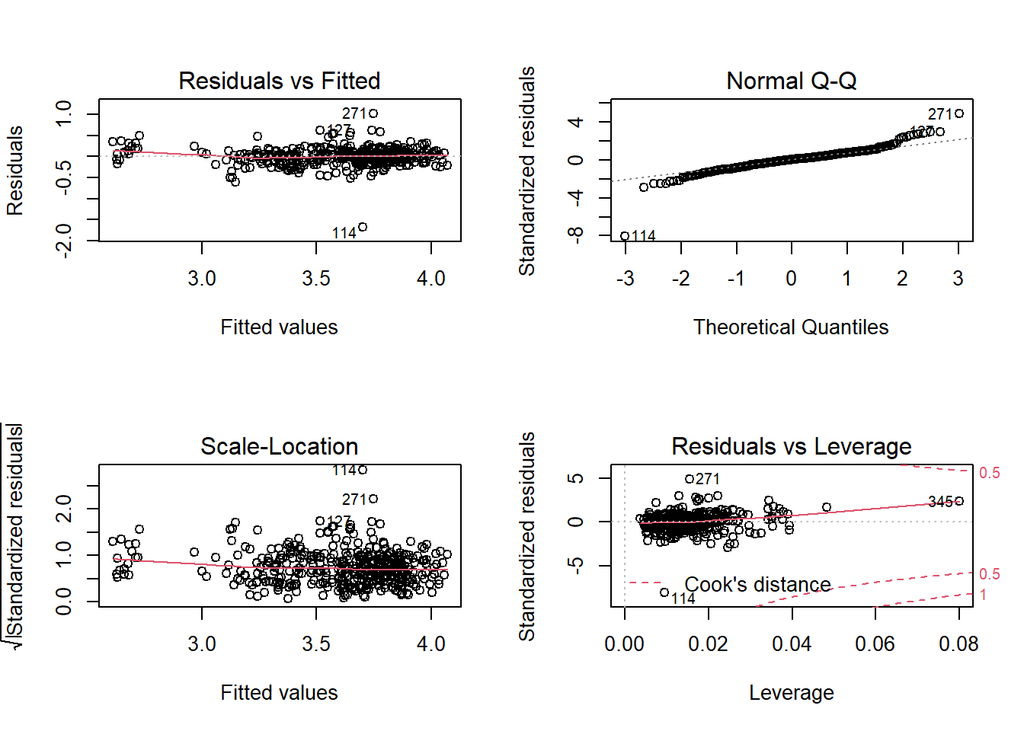

```r
#plot
op <- par(mfrow=c(2,2))
plot(rs)
```

Ta thấy đồ thị thể hiện mối tương quan của Residual vs Fitted và sqrt{standard residual} fit hơn so với ban đầu. Điều này có nghĩa với y=log(y) có tính ổn định hơn với mô hình ban đầu.

```r
#bptest
bptest(rs)
```

```
##
##  studentized Breusch-Pagan test
##
## data:  rs
## BP = 5.2002, df = 5, p-value = 0.3919
```

Với giả thuyết H(0) là phương sai không đổi, Giá trị p-value =0.39, vậy ta không đủ cơ sở để bác bỏ H(0) tức phương sai không có sự thay đổi. *Vậy: với Y=log(Y) ta thu được mô hình tốt hơn với hệ số xác định R cao hơn so với mô hình ban đầu.*